[figure not shown]

# Hablemos de los valores que circulan en nuestro mercado

El mercado de valores dominicano tenía **308 valores de oferta pública en circulación**, al 31 de julio del 2023, que podías adquirir teniendo una cuenta de corretaje en alguno de los puestos de bolsa autorizados por la SIMV.

Cada uno de estos valores está identificado por un código único llamado ISIN, por sus siglas en inglés (International Securities Identification Number). Esto es útil porque si deseas analizar o comprar unidades de cualquier valor en cualquier parte del mundo, este código te permite referirte inequívocamente al que te interesa.

### 1. ¿De cuánto dinero estamos hablando?

Mucho.

El valor nominal de todas las unidades en circulación de estos títulos alcanzaba los **2.54 billones de pesos**, al 31 de julio.

Te damos 3 ejemplos para poner esa cifra en perspectiva:

### 2. ¿En manos de quiénes están los valores de oferta pública?

El 33% de los 2.54 billones estaba concentrado en entidades de intermediación financiera. Este grupo incluye a los bancos múltiples, bancos de ahorros y créditos, y asociaciones de ahorros y préstamos.

En segundo y tercer lugar están los fondos de pensiones, que, en agregado alcanzan los 1.02 billones.

En cuarta posición, tenemos el grupo de personas físicas, quienes poseen 220,061 millones de pesos invertidos en instrumentos del mercado de valores.

El top 5 lo cierran los puestos de bolsa con DOP 134,860 millones.

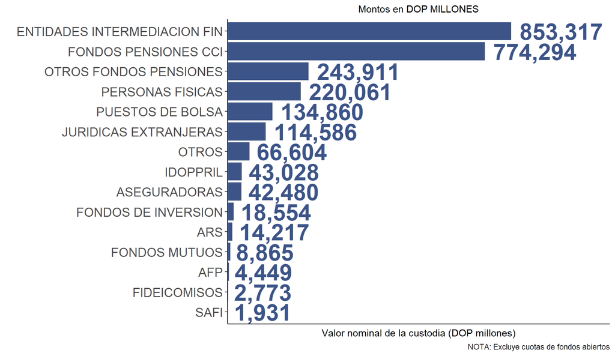

|  | Inversionista | Participantes | Monto (DOP millones) | % Total custodiado |
| --- | --- | --- | --- | --- |
| 1 | ENTIDADES INTERMEDIACION FIN | 39 | 853,317 | 33.54 |
| 2 | FONDOS PENSIONES CCI | 7 | 774,294 | 30.44 |
| 3 | OTROS FONDOS PENSIONES | 10 | 243,911 | 9.59 |
| 4 | PERSONAS FISICAS | 23499 | 220,061 | 8.65 |
| 5 | PUESTOS DE BOLSA | 14 | 134,860 | 5.3 |
| 6 | JURIDICAS EXTRANJERAS | 21 | 114,586 | 4.5 |
| 7 | OTROS | 697 | 66,604 | 2.62 |
| 8 | IDOPPRIL | 1 | 43,028 | 1.69 |
| 9 | ASEGURADORAS | 26 | 42,480 | 1.67 |
| 10 | FONDOS DE INVERSION | 29 | 18,554 | 0.73 |

[output cut: 6 more lines]

### 3. ¿En qué moneda están estos valores?

Los valores pueden emitirse en distintas monedas. La más popular es la moneda local: de los 308 valores vigentes, 171 están denominados en DOP pesos y 137 en USD. Quiere decir que el 56% fue emitido en pesos y el 44% fueron emitidos en dólares.

Ahora, las emisiones en pesos han sido mucho más grandes que las realizadas en dólares. Por eso, cuando vemos el desglose por moneda del monto de los valores, los 2.54 billones, la foto es distinta.

Debajo te mostramos cómo se ve.

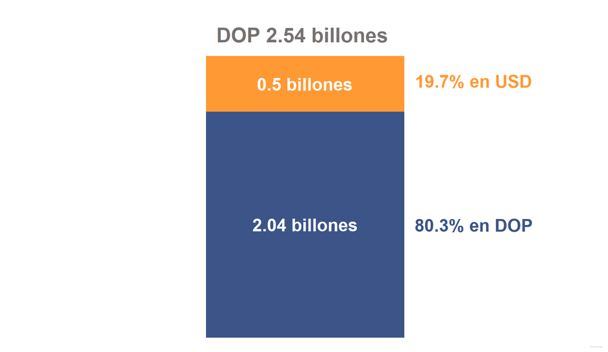

### 4. ¿Cuáles son los valores más populares?

Aquí te mostramos el top 10:

|  | ISIN | Valor | Moneda | Tasa | Inversionistas |
| --- | --- | --- | --- | --- | --- |
| 1 | DO1002225527 | NOTAS DEL BANCO CENTRAL VENC. 05-12-2025 | DOP | 13% | 3,770 |
| 2 | DO1002224926 | NOTAS DEL BANCO CENTRAL VENC. 03-10-2025 | DOP | 12% | 2,809 |
| 3 | DO1002226228 | NOTAS DEL BANCO CENTRAL VENC. 30-01-2026 | DOP | 13% | 2,286 |
| 4 | DO1002224629 | NOTAS DEL BANCO CENTRAL VENC 08-08-2025 | DOP | 12% | 2,226 |
| 5 | DO1002223928 | NOTA DEL BANCO CENTRAL VENC. 12-02-2027 | DOP | 8% | 1,641 |
| 6 | USP3579ECN50 | BONOS SOBERANOS USD 6,00 DOMINICAN, REP OF (REGS) 22-2033 | USD | 6% | 1,496 |
| 7 | DO1002224124 | NOTAS DEL BANCO CENTRAL VENC. 12-03-2027 | DOP | 8% | 1,479 |
| 8 | DO1002218720 | CERTIFICADO DE INVERSION ESPECIAL BCRD VENC. 14-02-2025 | DOP | 10.5% | 1,415 |
| 9 | DO1002218621 | NOTAS DEL BANCO CENTRAL VENC 17-01-25 | DOP | 10.5% | 1,311 |
| 10 | USP3579EBD87 | BONOS SOBERANOS RD USD VENC. 2025 | USD | 5.5% | 1,177 |